# EAI Tutorial 3.3

## Data Wrangling

Data wrangling is a process of reorganizing, transforming and re-mapping data from one “raw” form into another in order to make it more usable and valuable for a variety of downstream applications. For rectangular data, data wrangling is commonly handled in R by Tidyverse packages **tidyr** and **dplyr**.

### Data Frames

In R and Python, multivariate cross-sectional data — i.e. data in which each column is a variable/attribute/feature, and each row is an observation are represented by arrays, matrices, tables, data frames and tibbles . There are two flavors of rectangular data, differing mostly in the jargon used to name columns and rows.

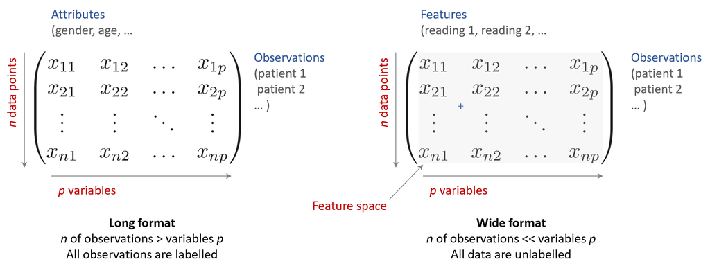

L**ong data** have the number of rows (observations) usually higher than the number of columns (attributes/variables) and in the **wide data** the arrangement is the other way around. In this tutorial, you will be dealing with long data.

### Dplyr: Grammar of DF Manipulation

**dplyr** implements a grammar of data manipulation, providing a consistent set of verbs that solve common rectangular data manipulation challenges. The following core functions are implemented to manipulate existing rows (observation), columns (variables), or aggregate existing data into new rows and columns.

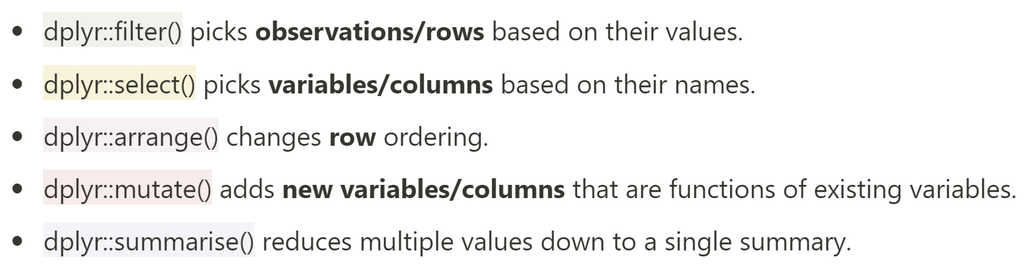

### Extracting Variables with `select()`

It is not uncommon to get data sets like `players_22.csv` with hundreds or even thousands of variables. `select()` allows us to rapidly zoom in on selected slices of data after providing the names of the variables. To work with less data on next iterations, we can select the appropriate columns like this:

```r
data %>%
  select(short_name, dob,
                skill_moves, skill_dribbling, skill_curve,
                skill_fk_accuracy, skill_long_passing, skill_ball_control) %>%
  print(n=3)
```

```
## # A tibble: 19,239 × 8
##   short_name        dob        skill_moves skill_dribbling skill_curve
##   <chr>             <date>           <dbl>           <dbl>       <dbl>
## 1 L. Messi          1987-06-24           4              96          93
## 2 R. Lewandowski    1988-08-21           4              85          79
## 3 Cristiano Ronaldo 1985-02-05           5              88          81
## # ℹ 19,236 more rows
## # ℹ 3 more variables: skill_fk_accuracy <dbl>, skill_long_passing <dbl>,
## #   skill_ball_control <dbl>
```

Including every skill columns into `select()` is tedious. Instead, it’s more convenient to combine helper functions together with `select()`. For example, you can add additional columns using *regex* matching for which rules can be defined. Some examples how this works are show below:

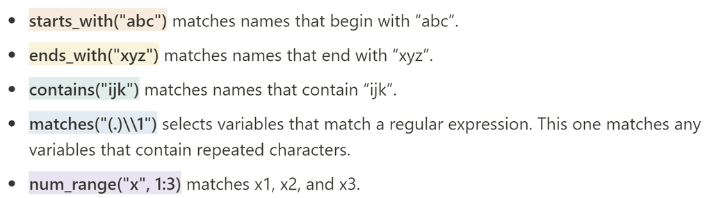

The way to think about `select()` is that that expression eventually evaluates to a logical vector. So if you use `starts_with()` it goes through the variables and asks which names start with the right set of characters.

```r
data %>%
  select(short_name, dob, starts_with("skill")) %>%
          print(n=3)
```

```
## # A tibble: 19,239 × 8
##   short_name        dob        skill_moves skill_dribbling skill_curve
##   <chr>             <date>           <dbl>           <dbl>       <dbl>
## 1 L. Messi          1987-06-24           4              96          93
## 2 R. Lewandowski    1988-08-21           4              85          79
## 3 Cristiano Ronaldo 1985-02-05           5              88          81
## # ℹ 19,236 more rows
## # ℹ 3 more variables: skill_fk_accuracy <dbl>, skill_long_passing <dbl>,
## #   skill_ball_control <dbl>
```

Similarly, you can use `where()`, which takes a function and returns all variables for which the function returns TRUE.

```r
data %>%
  select(short_name, dob, where(is.numeric)) %>%
  print(n=3)
```

```
## # A tibble: 19,239 × 62
##   short_name     dob        sofifa_id overall potential value_eur wage_eur   age
##   <chr>          <date>         <dbl>   <dbl>     <dbl>     <dbl>    <dbl> <dbl>
## 1 L. Messi       1987-06-24    158023      93        93  78000000   320000    34
## 2 R. Lewandowski 1988-08-21    188545      92        92 119500000   270000    32
## 3 Cristiano Ron… 1985-02-05     20801      91        91  45000000   270000    36
## # ℹ 19,236 more rows
## # ℹ 54 more variables: height_cm <dbl>, weight_kg <dbl>, club_team_id <dbl>,
## #   league_level <dbl>, club_jersey_number <dbl>,
## #   club_contract_valid_until <dbl>, nationality_id <dbl>,
## #   nation_team_id <dbl>, nation_jersey_number <dbl>, weak_foot <dbl>,
## #   skill_moves <dbl>, international_reputation <dbl>,
## #   release_clause_eur <dbl>, pace <dbl>, shooting <dbl>, passing <dbl>, …
```

### Extracting Variables with `.`

Square bracket `[` subsetting is handy, but it can be cumbersome and difficult to read, especially for complicated operations. `select()`, on the other hand, is plainly understood. The downside is that it does not allow customizing object type on return.

> This causes problems on the ML end because these functions need vector(s) as their input.

Say, you want to extract a single column of a data frame as an atomic vector. Subsetting the original data frame with `select()` leads to preserving subsetting.

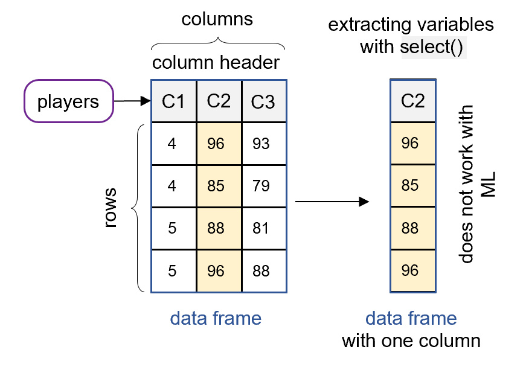

To extract an atomic vector from a data frame, use the `.` operator together with the $ sign operator. A viable alternative is `pull()`. Both options will do simplifying subsetting.

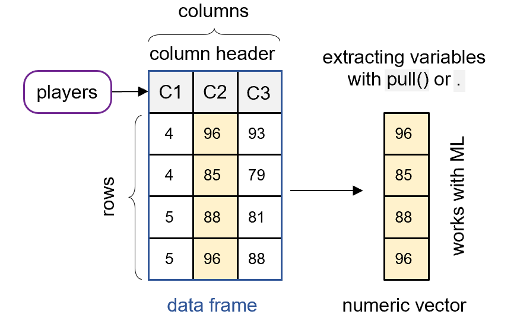

```r
 typeof(data %>% .$skill_dribbling) # This code extracts numeric vector of dribbling values.
```

```
## [1] "double"
```

**Task 1:** Load `players_22.csv` into R. Use `select()` to remove all columns except of `skill_dribbling`. What type and class of the object is returned? Does this object still has a column name(s)?

### Extracting Observations with `filter()`

`filter()` allows you to select observations based on their values. For example, let’s takte the FIFA22 data and select players with dribbling skill above average with following code:

```r
data %>%
  select(short_name, dob, starts_with("skill")) %>%
  filter(skill_dribbling > mean(data$skill_dribbling)) %>%
  print(n=5)
```

```
## # A tibble: 12,643 × 8
##   short_name        dob        skill_moves skill_dribbling skill_curve
##   <chr>             <date>           <dbl>           <dbl>       <dbl>
## 1 L. Messi          1987-06-24           4              96          93
## 2 R. Lewandowski    1988-08-21           4              85          79
## 3 Cristiano Ronaldo 1985-02-05           5              88          81
## 4 Neymar Jr         1992-02-05           5              95          88
## 5 K. De Bruyne      1991-06-28           4              88          85
## # ℹ 12,638 more rows
## # ℹ 3 more variables: skill_fk_accuracy <dbl>, skill_long_passing <dbl>,
## #   skill_ball_control <dbl>
```

You can combine multiple `filter()` parameters with “`&` (and)” and “`|` (or)”, representing logical AND and logical OR.

**Task 2:** Examine a R code that selects players with dribbling skills between 80 and 90. Would the following code work? If not, find the way to fix it.

```r
data %>%
  filter(skill_dribbling > 80 & < 90)
```

### The `%in%` Operator

```r
data %>%
  select(short_name, dob, starts_with("skill")) %>%
  filter(short_name %in% c("R. Lewandowski", "Cristiano Ronaldo", "Neymar Jr")) %>%
  print(n=3)
```

```
## # A tibble: 3 × 8
##   short_name        dob        skill_moves skill_dribbling skill_curve
##   <chr>             <date>           <dbl>           <dbl>       <dbl>
## 1 R. Lewandowski    1988-08-21           4              85          79
## 2 Cristiano Ronaldo 1985-02-05           5              88          81
## 3 Neymar Jr         1992-02-05           5              95          88
## # ℹ 3 more variables: skill_fk_accuracy <dbl>, skill_long_passing <dbl>,
## #   skill_ball_control <dbl>
```

## Data Frame Operations

### Column Modification with `mutate()`

**`mutate()`** is a function for creating new variables from existing ones. If you want to keep only the new column and discard all other columns, use `transmute()`.

#### Creating a New Column

For example, let’s mean-normalize `skill_dribbling` values and append normalized values as a new column.

> Mean-normalized values are normally refereed to as the **relative values** and as such, they are suited for interpretation. ML guys generally love relative values. The original values are often refereed to as **absolute values**.

Notice that the new column will be appended at the end of a data frame.

```r
data %>%
  select(short_name, dob, starts_with("skill")) %>%
  filter(short_name %in% c("R. Lewandowski", "Cristiano Ronaldo", "Neymar Jr")) %>%
  filter(skill_dribbling > mean(data$skill_dribbling)) %>%
  mutate(normalized_SD = skill_dribbling - mean(data$skill_dribbling))
```

```
## # A tibble: 3 × 9
##   short_name        dob        skill_moves skill_dribbling skill_curve
##   <chr>             <date>           <dbl>           <dbl>       <dbl>
## 1 R. Lewandowski    1988-08-21           4              85          79
## 2 Cristiano Ronaldo 1985-02-05           5              88          81
## 3 Neymar Jr         1992-02-05           5              95          88
## # ℹ 4 more variables: skill_fk_accuracy <dbl>, skill_long_passing <dbl>,
## #   skill_ball_control <dbl>, normalized_SD <dbl>
```

#### Modifying an Existing Column

You can also modify existing columns as shown on a last line of the following code. In that case, the modified column is not moved away from its original position.

```r
data %>%
  select(short_name, dob, starts_with("skill")) %>%
  filter(short_name %in% c("R. Lewandowski", "Cristiano Ronaldo", "Neymar Jr")) %>%
  filter(skill_dribbling > mean(data$skill_dribbling)) %>%
  mutate(skill_dribbling = skill_dribbling - mean(data$skill_dribbling))
```

```
## # A tibble: 3 × 8
##   short_name        dob        skill_moves skill_dribbling skill_curve
##   <chr>             <date>           <dbl>           <dbl>       <dbl>
## 1 R. Lewandowski    1988-08-21           4            29.3          79
## 2 Cristiano Ronaldo 1985-02-05           5            32.3          81
## 3 Neymar Jr         1992-02-05           5            39.3          88
## # ℹ 3 more variables: skill_fk_accuracy <dbl>, skill_long_passing <dbl>,
## #   skill_ball_control <dbl>
```

#### Modifying Multiple Columns with `across()`

`across()` makes it easy to transform multiple columns. This is one of helper functions that work only inside inside in “data-masking” functions like `summarise()` and `mutate()`.

```r
data %>%
  select(short_name, dob, starts_with("skill")) %>%
  filter(short_name %in% c("R. Lewandowski", "Cristiano Ronaldo", "Neymar Jr")) %>%
  mutate(across(where(is.numeric), as.integer))
```

```
## # A tibble: 3 × 8
##   short_name        dob        skill_moves skill_dribbling skill_curve
##   <chr>             <date>           <int>           <int>       <int>
## 1 R. Lewandowski    1988-08-21           4              85          79
## 2 Cristiano Ronaldo 1985-02-05           5              88          81
## 3 Neymar Jr         1992-02-05           5              95          88
## # ℹ 3 more variables: skill_fk_accuracy <int>, skill_long_passing <int>,
## #   skill_ball_control <int>
```

### Renaming Columns with `rename()`

`rename()` changes the column name to a new value.

```r
data %>%
  select(short_name, dob, starts_with("skill")) %>%
  filter(short_name %in% c("R. Lewandowski", "Cristiano Ronaldo", "Neymar Jr")) %>%
  rename(date_of_birth = dob)
```

```
## # A tibble: 3 × 8
##   short_name        date_of_birth skill_moves skill_dribbling skill_curve
##   <chr>             <date>              <dbl>           <dbl>       <dbl>
## 1 R. Lewandowski    1988-08-21              4              85          79
## 2 Cristiano Ronaldo 1985-02-05              5              88          81
## 3 Neymar Jr         1992-02-05              5              95          88
## # ℹ 3 more variables: skill_fk_accuracy <dbl>, skill_long_passing <dbl>,
## #   skill_ball_control <dbl>
```

### Rearrange Columns with `relocate()`

`relocate()` offers a very intuitive way to arrange columns. You only need to specify columns to be moved and their new position with either `.before=` or `.after=`. `relocate()` is a shorthand for `select()`, meaning that everything that can be done with `relocate()` can be done with `select()`.

```r
data %>%
  select(short_name, dob, starts_with("skill")) %>%
  filter(short_name %in% c("R. Lewandowski", "Cristiano Ronaldo", "Neymar Jr")) %>%
  relocate(starts_with("skill"), .after = short_name)
```

```
## # A tibble: 3 × 8
##   short_name        skill_moves skill_dribbling skill_curve skill_fk_accuracy
##   <chr>                   <dbl>           <dbl>       <dbl>             <dbl>
## 1 R. Lewandowski              4              85          79                85
## 2 Cristiano Ronaldo           5              88          81                84
## 3 Neymar Jr                   5              95          88                87
## # ℹ 3 more variables: skill_long_passing <dbl>, skill_ball_control <dbl>,
## #   dob <date>
```

```r
data %>%
  select(short_name, dob, starts_with("skill")) %>%
  filter(short_name %in% c("R. Lewandowski", "Cristiano Ronaldo", "Neymar Jr")) %>%
  relocate(where(is.numeric), .before = where(is.character))
```

```
## # A tibble: 3 × 8
##   skill_moves skill_dribbling skill_curve skill_fk_accuracy skill_long_passing
##         <dbl>           <dbl>       <dbl>             <dbl>              <dbl>
## 1           4              85          79                85                 70
## 2           5              88          81                84                 77
## 3           5              95          88                87                 81
## # ℹ 3 more variables: skill_ball_control <dbl>, short_name <chr>, dob <date>
```

### Insert Rows with `add_rows()`

Tibbles and data frames work reasonably well with `rbind()` and `cbind()` functions, which insert one or more rows at the end of the data frame.

You can also get the same thing done with functions such as `add_row()` and `rows_inset()`. The row length of the original and inserted data frames must be the same.

```r
tmp <- data %>%
  select(short_name, value_eur) %>%
  filter(short_name == "L. Messi")

tmp %>% add_row(short_name = "P. Belej", value_eur = 10000)
```

```
## # A tibble: 2 × 2
##   short_name value_eur
##   <chr>          <dbl>
## 1 L. Messi    78000000
## 2 P. Belej       10000
```

## Aggregate Summary Reports

Data aggregation is a process whereby data is gathered and expressed in a summary form. When data is aggregated, rows and columns are replaced with summary statistics (such as totals, means, standard deviation…).

The original table ceases to exist. Instead, a smaller table is generated which can be pivoted, transformed and summarized again.

### Summary Statistics with `summarise()`

In R, summary statistics are generated with the `summarise()` function. `summarise()` can be cumbersome function to use because it requires you to enumerate every statistic you use for every variable.

```r
data %>%
  select(short_name, dob, skill_dribbling) %>%
  summarise(mean_dribbling = mean(skill_dribbling),
            min_dribbling = min(skill_dribbling),
            max_dribbling = max(skill_dribbling),
            number_of_records = n())
```

```
## # A tibble: 1 × 4
##   mean_dribbling min_dribbling max_dribbling number_of_records
##            <dbl>         <dbl>         <dbl>             <int>
## 1           55.7             4            96             19239
```

```r
# n() is a shorthand function for number of rows.
# tally() does the same thing, but also works outside summarise().
```

A viable alternative are **listed-functions** and **functionals**, such as `map()`.

**Task 3:** Check the type of the output of `summarise()` from the previous example. Does it have any interesting attributes and can these attributes be changed? Apply `summary()` and `attributes()` on the resulting object. What type of an object did you get? Does it have any attributes and can these attributes be changed?

**Task 4:** Are any interesting helper functions that work with `summarise()`? Check R cheat sheets to find out.

### Data Aggregation with `group_by()`

Summary statistics are often not calculated on the whole dataset, but on groups (e.g. player’s position: goal keeper, forward, center, …). `group_by()` uses that information to break down an existing table into groups of nested data frames, on which operations are performed. The resulting compuations are then aggregated into a table or a list.

```r
data %>%
  select(short_name, dob, league_level, skill_dribbling) %>%
  group_by(league_level) %>%
  summarise(mean_dribbling = mean(skill_dribbling),
            min_dribbling = min(skill_dribbling),
            max_dribbling = max(skill_dribbling),
            number_of_records = n())
```

```
## # A tibble: 6 × 5
##   league_level mean_dribbling min_dribbling max_dribbling number_of_records
##          <dbl>          <dbl>         <dbl>         <dbl>             <int>
## 1            1           56.0             4            96             14857
## 2            2           56.1             5            85              2513
## 3            3           52.8             4            75              1168
## 4            4           51.5             5            71               613
## 5            5           48.9             5            65                27
## 6           NA           55.4             7            78                61
```

### Ordering rows with `arrange()`

`arrange()` orders the rows of a data frame by the values of selected columns.

Unlike other dplyr verbs, `arrange()` largely ignores grouping; you need to explicitly mention grouping variables (or use `.by_group = TRUE`) in order to group by them, and functions of variables are evaluated once per data frame, not once per group. Use `desc()` for arrangement in a descending order.

```r
data %>%
  select(short_name, dob, league_level, skill_dribbling) %>%
  arrange(desc(skill_dribbling))
```

```
## # A tibble: 19,239 × 4
##    short_name     dob        league_level skill_dribbling
##    <chr>          <date>            <dbl>           <dbl>
##  1 L. Messi       1987-06-24            1              96
##  2 Neymar Jr      1992-02-05            1              95
##  3 K. Mbappé      1998-12-20            1              93
##  4 J. Sancho      2000-03-25            1              92
##  5 Bernardo Silva 1994-08-10            1              92
##  6 Adama Traoré   1996-01-25            1              92
##  7 M. Verratti    1992-11-05            1              91
##  8 R. Mahrez      1991-02-21            1              91
##  9 Isco           1992-04-21            1              91
## 10 W. Zaha        1992-11-10            1              91
## # ℹ 19,229 more rows
```